# league2

## Summary of Findings

### Introduction

The prediction problem that we aim to answer in this project, is to predict whether an individual `wins` or `loses` based on their stats during the game.

This is a classification problem as each game can only be classified as a `win` or a `lost`. The metric that we decided to use to score our model, is accuracy. We chose accuracy as the knowledge of the false positives and the false negatives are not as important to the effectiveness of the model as compared to the accuracy.

### Baseline Model

For our baseline model, we first looked at the overall dataset to determine which columns would have the most weightage to predicting a `win` or `lost`.

##### Nominals

- `patch`
  - For `patch` we OneHotEncoded
- `position`
  - For `position` we OneHotEncoded
- `champion`
  - For `Champion` we OneHotEncoded

##### Quatitative

- `gamelength`
- `kills`
- `deaths`
- `assists`
- `teamkills`
- `teamdeaths`
- `total cs`
- `dpm`(Damage per Minute)
- `damagetakenperminute`
- `earned gpm`

### Final Model

##### Additional Features

To improve the model, first we binarized `dpm`, `damagetakenperminute` and `earned gpm` as we didn't want overly highly/low values to weight heavily on the result. An example of how this can occur is when carries will tend to have higher `dpm` as they are the damage dealers in a team as compared to a non-carry position.

In the previous project we did an analysis on how `kda` (Kill, death and assists ratio) varies between roles so we thought it might have an impact on the likelihood of winning a game as well. Therefore we transformed the columns `kills`, `deaths` and `assists` into one column called `kda`.

##### Model and Hyperparameter Selection

To determine the best classifier model and the best hyperparameters for the prediction. We did a grid multiple gridsearches and compared the cross validation scores on all of them to select the best model.

We chose Decision Decision with the best parameters as our final model, as looking at all the grid searches, it had the highest accuracy on test data and second best cross vaildation score losing out to Logistical Regression by a negligible margin.

Therefore we chose **Decision Tree** as our **Final Model**

### Fairness Evaluation

For our fairness evaluation we chose the subset as 'High' `teamkills` and 'Low' `teamkills` to test whether the model is fair in terms of a players teams total kills or not. To determin the threshold for 'High' / 'Low' kills, we took the 75th percentile of all `teamkills` as the threshold.

The parity measure that we will be using is the accuracy score as we only care about correct predictions within each subset.

##### Permuation Test

**Null**: The model is fair, as the accuracy between the 2 subsets are roughly the same **Alternative**: The model is unfair, as the accuracy between theh 2 subsets are not equal.

As seen in the code, we fail to reject the Null. Which means that there is no biasness between 'High' `teamkills` and 'Low' `teamkill` meaning our model is fair.

# Code

```python
import matplotlib.pyplot as plt
import numpy as np
import os
import pandas as pd
import seaborn as sns
from sklearn.preprocessing import FunctionTransformer, Binarizer, OneHotEncoder
from sklearn.model_selection import train_test_split
from sklearn.pipeline import Pipeline
from sklearn.compose import ColumnTransformer
%matplotlib inline
%config InlineBackend.figure_format = 'retina'  # Higher resolution figures
```

### Baseline Model

```python
df = pd.read_csv('data/2022_LoL.csv')
df_clean = df[df['position'] != 'team']
df_clean = df_clean[df_clean['datacompleteness'] != 'partial']
```

```python
# Features that were determined were relevant
feats = df_clean[[
    'patch', 'position', 'champion', 'gamelength',
    'kills', 'deaths', 'assists',
    'teamkills', 'teamdeaths', 'total cs',
    'dpm', 'damagetakenperminute', 'earned gpm'
]]
results = df_clean['result']

# Train Test split
train_x, test_x, train_y, test_y = train_test_split(feats, results)
train_x.head()
```

|  | patch | position | champion | gamelength | kills | deaths | assists | teamkills | teamdeaths | total cs | dpm | damagetakenperminute | earned gpm |
| --- | --- | --- | --- | --- | --- | --- | --- | --- | --- | --- | --- | --- | --- |
| 91704 | 12.11 | top | Camille | 1959 | 5 | 1 | 8 | 18 | 8 | 239.0 | 414.0582 | 739.2649 | 313.3538 |
| 115256 | 12.13 | bot | Draven | 1355 | 1 | 4 | 1 | 3 | 15 | 178.0 | 364.7380 | 390.5535 | 200.5461 |
| 144674 | 12.18 | mid | Akali | 1626 | 3 | 4 | 5 | 9 | 21 | 191.0 | 468.8192 | 771.2546 | 215.1661 |
| 141552 | 12.18 | top | Ornn | 2331 | 3 | 9 | 11 | 18 | 30 | 207.0 | 699.0991 | 1260.7979 | 203.5779 |
| 22016 | 12.03 | bot | Aphelios | 1994 | 2 | 0 | 11 | 18 | 9 | 314.0 | 583.7212 | 282.3671 | 327.1414 |

```python
# Preprocessing steps for model
preproc = ColumnTransformer([
    ('ohe_champs_pos', OneHotEncoder(sparse=False, handle_unknown='ignore'), ['champion', 'position', 'patch']),
], remainder='passthrough')

preproc.fit_transform(train_x)[:10]
```

```
array([[  0.    ,   0.    ,   0.    , ..., 414.0582, 739.2649, 313.3538],
       [  0.    ,   0.    ,   0.    , ..., 364.738 , 390.5535, 200.5461],
       [  0.    ,   0.    ,   1.    , ..., 468.8192, 771.2546, 215.1661],
       ...,
       [  0.    ,   0.    ,   0.    , ..., 287.4164, 692.8632, 253.8602],
       [  0.    ,   0.    ,   0.    , ..., 132.6464, 525.9766, 120.6464],
       [  0.    ,   0.    ,   0.    , ..., 531.1989, 546.1397, 257.6548]])
```

```python
# Baseline model using Decision Tree
from sklearn.tree import DecisionTreeClassifier

pl = Pipeline([
    ('preprocessing',  preproc),
    ('dt', DecisionTreeClassifier())
])

pl.fit(train_x, train_y)
pl.predict(test_x)
pl.score(test_x, test_y) # Accuracy
```

```
0.9679379394680526
```

```
<sklearn.metrics._plot.confusion_matrix.ConfusionMatrixDisplay at 0x2169cca2df0>
```

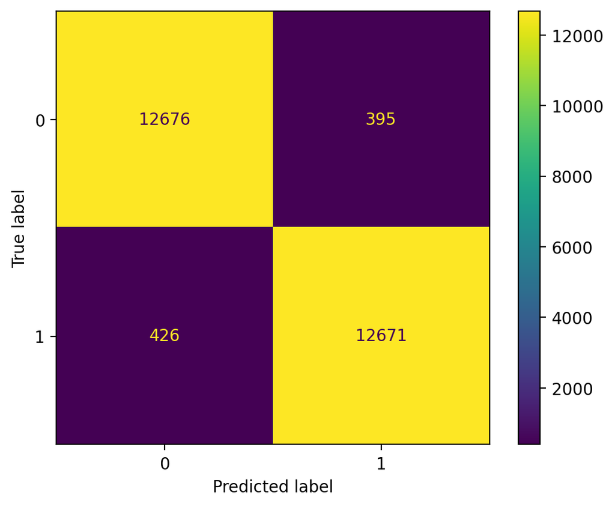

```python
from sklearn.metrics import plot_confusion_matrix
import warnings
pl = Pipeline([
    ('preprocessing',  preproc),
    ('dt', DecisionTreeClassifier())
])

warnings.simplefilter('ignore')

pl.fit(train_x, train_y)
y_pred = pl.predict(train_x)
pl.score(test_x, test_y)
plot_confusion_matrix(pl, test_x, test_y)
```

### Final Model

```python
from sklearn.model_selection import GridSearchCV
from sklearn.linear_model import LogisticRegression
from sklearn.ensemble import RandomForestClassifier
from sklearn.neighbors import KNeighborsClassifier
```

```python
feats[['dpm', 'damagetakenperminute', 'earned gpm']].describe()
```

|  | dpm | damagetakenperminute | earned gpm |
| --- | --- | --- | --- |
| count | 104670.000000 | 104670.000000 | 104670.000000 |
| mean | 418.668644 | 587.590700 | 228.937327 |
| std | 232.170156 | 244.839004 | 87.520314 |
| min | 0.000000 | 0.000000 | 9.411800 |
| 25% | 234.578350 | 396.144325 | 166.017300 |
| 50% | 388.976300 | 545.355050 | 231.035450 |
| 75% | 560.765850 | 764.966800 | 290.740200 |
| max | 1947.272700 | 2126.743800 | 690.265100 |

```python
def kda(df):
    """Function to calculate kda

    Args:
        df (pandas dataframe): Dataframe with the columns, kills, deaths, assists

    Returns:
        Pandas Dataframe: Dataframe of the kda
    """
    df = pd.DataFrame((df['kills'] + df['assists'])/df['deaths'])
    max_not_inf = df[df[0] != np.inf].max()
    return df.replace(np.inf, max_not_inf).fillna(0).astype(float)

kda_trans = FunctionTransformer(kda)

pl_kda_standardize = Pipeline([
    ('kda', kda_trans)
])
```

```python
preproc = ColumnTransformer([
    ('kda_standardize', pl_kda_standardize, ['kills', 'deaths', 'assists']),
    ('ohe_champs_pos', OneHotEncoder(sparse=False, handle_unknown='ignore'), ['champion', 'position', 'patch']),
    # Thresholds for dpm, dtpm, gpm are the means
    ('binarize_dpm', Binarizer(threshold=419), ['dpm']),
    ('binarize_dtpm', Binarizer(threshold=588), ['damagetakenperminute']),
    ('binarize_gpm', Binarizer(threshold=229), ['earned gpm'])
], remainder='passthrough')

preproc.fit_transform(train_x)[:10]
```

```
array([[ 13.        ,   0.        ,   0.        , ...,  18.        ,
          8.        , 239.        ],
       [  0.5       ,   0.        ,   0.        , ...,   3.        ,
         15.        , 178.        ],
       [  2.        ,   0.        ,   0.        , ...,   9.        ,
         21.        , 191.        ],
       ...,
       [  1.66666667,   0.        ,   0.        , ...,   7.        ,
         20.        , 175.        ],
       [  4.75      ,   0.        ,   0.        , ...,  23.        ,
         15.        ,  38.        ],
       [  3.33333333,   0.        ,   0.        , ...,  15.        ,
         16.        , 284.        ]])
```

```python
# Decision Tree pipeline
pl_dt = Pipeline([
    ('preprocessing',  preproc),
    ('DT', DecisionTreeClassifier())
])
#Hyperparameters for the grid search on decision tree
hyperparameters_dt = {
    'DT__max_depth': [10, 15, 18, None],
    'DT__criterion': ['gini', 'entropy'],
    'DT__min_samples_split': [2, 4, 8, 16]
}
# Gridsearch
searcher_dt = GridSearchCV(pl_dt, hyperparameters_dt)
searcher_dt.fit(train_x, train_y)
searcher_dt.best_params_ #Final Model
```

```
{'DT__criterion': 'entropy', 'DT__max_depth': 18, 'DT__min_samples_split': 4}
```

```python
# {'DT__criterion': 'entropy', 'DT__max_depth': 18, 'DT__min_samples_split': 4}
searcher_dt.score(test_x, test_y) #Accuracy
```

```
0.96170895750535
```

```python
searcher_dt.best_score_ #Cross Validation Score
```

```
0.9571603569410362
```

```python
#Pipeline for Random Forest
pl_rf = Pipeline([
    ('preprocessing',  preproc),
    ('RF', RandomForestClassifier())
])
#Hyperparameters for Random Forest
hyperparameters_rf = {
    'RF__n_estimators': [100,200],
    'RF__max_depth': [15],
    'RF__criterion': ['entropy'],
    'RF__min_samples_split': [4]
}
searcher_rf = GridSearchCV(pl_rf, hyperparameters_rf)
searcher_rf.fit(train_x, train_y)
searcher_rf.best_params_
```

```
{'RF__criterion': 'entropy',
 'RF__max_depth': 15,
 'RF__min_samples_split': 4,
 'RF__n_estimators': 200}
```

```python
# {'RF__criterion': 'entropy','RF__max_depth': 15,'RF__min_samples_split': 4,'RF__n_estimators': 200}
searcher_rf.score(test_x, test_y) # Accuracy
```

```
0.9499757967949861
```

```python
searcher_rf.best_score_ # Cross Validation Score
```

```
0.9410970724003542
```

```python
# Logistical Regression Pipeline
pl_LR = Pipeline([
    ('preprocessing',  preproc),
    ('LR', LogisticRegression())
])
# HyperParameters for Logistical Regressio
hyperparameters_LR = {
    'LR__penalty': ['l2'],
    'LR__C': [1],
    'LR__max_iter': [50, 100, 200]
}
searcher_LR = GridSearchCV(pl_LR, hyperparameters_LR)
searcher_LR.fit(train_x, train_y)
searcher_LR.best_params_
```

```
{'LR__C': 1, 'LR__max_iter': 100, 'LR__penalty': 'l2'}
```

```python
# {'LR__C': 1, 'LR__max_iter': 100, 'LR__penalty': 'l2'}
searcher_LR.score(test_x, test_y) # Accuracy
```

```
0.9579257107918068
```

```python
searcher_LR.best_score_ # Cross Validation Score
```

```
0.9584469430118656
```

```python
# KNeighbors Classifiers Pipeline
pl_KNC = Pipeline([
    ('preprocessing',  preproc),
    ('KNC', KNeighborsClassifier())
])
# Hyperparameters for KNeighbors
hyperparameters_KNC = {
    'KNC__n_neighbors': [2, 3, 5],
    'KNC__weights': ['uniform', 'distance'],
}
searcher_KNC = GridSearchCV(pl_KNC, hyperparameters_KNC)
searcher_KNC.fit(train_x, train_y)
searcher_KNC.best_params_
```

```
{'KNC__n_neighbors': 5, 'KNC__weights': 'distance'}
```

```python
searcher_KNC.score(test_x, test_y) # Accuracy
```

```
0.9293793946805259
```

```python
searcher_KNC.best_score_ # Cross Validation score
```

```
0.9305368524946888
```

### Fairness Evaluation

```python
feats.describe()[['kills', 'teamkills']]
```

|  | kills | teamkills |
| --- | --- | --- |
| count | 104670.000000 | 104670.000000 |
| mean | 2.912554 | 14.562769 |
| std | 2.752270 | 7.566761 |
| min | 0.000000 | 0.000000 |
| 25% | 1.000000 | 8.000000 |
| 50% | 2.000000 | 14.000000 |
| 75% | 4.000000 | 20.000000 |
| max | 28.000000 | 60.000000 |

```python
# Using Gridsearch output model to get predicted values for fairness evaluation
preds = searcher_dt.predict(test_x)
```

```python
from sklearn.metrics import accuracy_score
# Adding actual, predicted and split
results = test_x.copy()
results['over_20_kills'] = results['teamkills'].apply(lambda x: 1 if x > 20 else 0)
results['predictions'] = preds
results['actual'] = test_y
accuracy_score(test_y, preds)
```

```
0.96170895750535
```

```python
# Dataframe to see relationship between precision of the split
results.groupby('over_20_kills')\
       .apply(lambda x: accuracy_score(x['actual'], x['predictions']))\
       .rename('accuracy').to_frame()
# 0 is less than equal 20, 1 is more than
```

| over_20_kills | accuracy |
| --- | --- |
| 0 | 0.963096 |
| 1 | 0.956914 |

```python
# Performing our Permuatation Test
obsv = results.groupby('over_20_kills')\
              .apply(lambda x: accuracy_score(x['actual'], x['predictions']))\
              .diff().iloc[-1]
obsv # Our observed value
```

```
-0.006182007649189747
```

```python
# Permuatation Test
diff_in_acc = []
for _ in range(1000):
    # Shuffling and calculation difference in precision score between players whose team had over 20 kills
    # And those that didn't
    s = (
        results[['over_20_kills', 'predictions', 'actual']]
        .assign(over_20_kills=results.over_20_kills.sample(frac=1.0, replace=False).reset_index(drop=True))
        .groupby('over_20_kills')
        .apply(lambda x: accuracy_score(x['actual'], x['predictions']))
        .diff()
        .iloc[-1]
    )

    diff_in_acc.append(s)

# Calculating the Pvalue
sims = pd.Series(diff_in_acc)
p_val = len(sims[sims >= obsv]) / len(sims)
p_val
```

```
0.818
```

[figure not shown]

```python
# Plot of observations
plt.figure(figsize=(10, 5))
pd.Series(diff_in_acc).plot(kind='hist',
                            ec='w',
                            density=True,
                            bins=15,
                            title='Difference in Accuracy (Low Kills - High Kills)',
                            label = 'Difference in Accuracy')
plt.axvline(x=obsv, color='red', label='observed difference in Accuracy')
plt.legend(loc='upper left');
```